# Confidence Intervals

## t-Confidence Intervals

- From the Central Limit Theorem (CLT) we created a confidence interval using $Est \pm ZQ \times SEest$ (estimated value plus/minus the quantile of the normal times the standard error of the estimated value).
- For small samples we can use Gosset’s t-distribution and t-confidence intervals which take the form $Est \pm TQ \times SEest$

$$\dfrac{\bar{X} - \mu}{S/\sqrt{n}}$$

$$\bar{X} \pm t_{n-1}S/\sqrt{n}$$

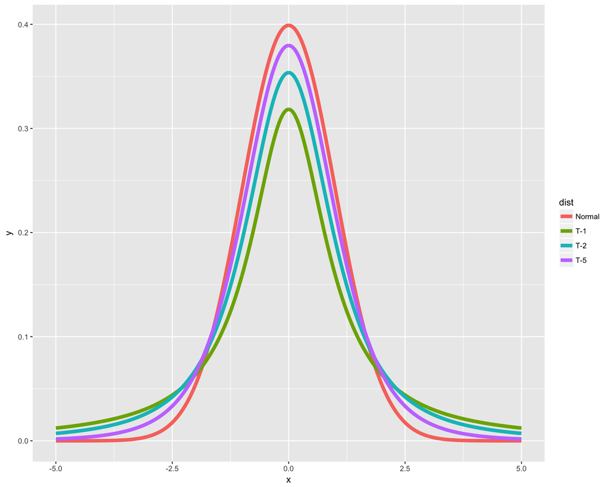

```r
k <- 1000
df <- 1
xvals <- seq(-5, 5, length = k)
d <- data.frame(y = c(dnorm(xvals), dt(xvals, 1), dt(xvals, 2), dt(xvals, 5)),
                x = xvals,
                dist = factor(rep(c("Normal", "T-1", "T-2", "T-5"), c(k,k,k,k))))


g <- ggplot(d, aes(x = x, y = y))
g <- g + geom_line(size = 2, aes(color = dist))
g
```

## Exercises

### Question 1

For iid Gaussian data, the statistic $\dfrac{\bar{X} - \mu}{S/\sqrt{n}}$ must follow a:

- Z distribution
- t distribution

**Answer:** t distribution, with n-1 degrees of freedom.

### Question 2

Paired differences T confidence intervals are useful when:

- Pairs of observations are linked, such as when there is subject level matching or in a study with baseline and follow up measurements on all participants.
- When there was randomization of a treatment between two independent groups.

**Answer:** When pairs of observations are linked

### Question 3

The assumption that the variances are equal for the independent group T interval means that:

- The sample variances have to be nearly identical.
- The population variances are identical, but the sample variances may be different.

### Question 4

Load the data set `mtcars` in the `datasets` R package. Calculate a 95% confidence interval to the nearest MPG for the variable mpg.